# Hydrogen Atom: Shifts and Interactions

Author

Daniel Fischer

## Introduction

As we have seen in the Hydrogen (Wave Functions) chapter, the Schrödinger picture gives a remarkably simple description of the hydrogen atom. The energy levels depend only on the principal quantum number $n$:

$$E_n = -\frac{13.6\ \mathrm{eV}}{n^2}.$$

In that approximation the spectrum looks simple: photon energies correspond to energy differences between levels and appear in well known *series* (see left figure below):

- **Lyman**: transitions to $n_\ell=1$ (ultraviolet)
- **Balmer**: transitions to $n_\ell=2$ (visible)
- **Paschen, Brackett, Pfund, …**: transitions to $n_\ell=3,4,5,\dots$ (infrared)

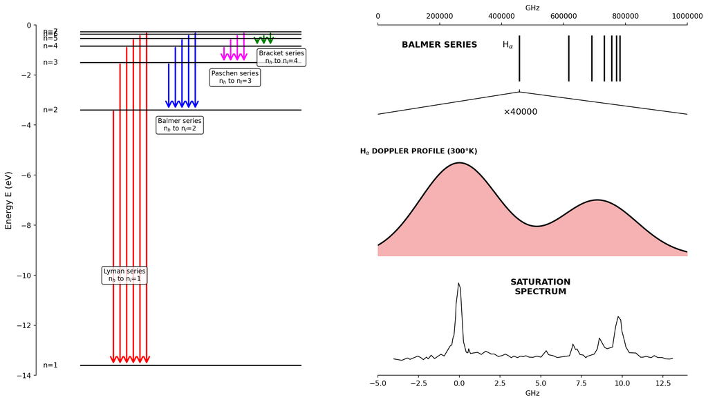

Illustration of hydrogen spectral series. (*Left*) Energy-level diagram showing the Lyman, Balmer, and Paschen series. (*Top right*) Balmer spectrum. (*Middle right*) Example of Doppler broadening in a hydrogen line. (*Bottom right*) High-resolution spectrum revealing fine structure. The experimental spectrum is based on data extracted from *A. L. Schawlow, Lasers, light, and matter, J. Opt. Soc. Am. 67, 140–147 (1977)*.

## A closer look — why the simple picture fails

High-resolution and careful experiments show that many spectral lines are not single sharp lines as the simple Schrödinger model predicts. Instead they are **shifted** and **split** by small amounts (see right figure above). These discrepancies point to additional physics that is not contained in the nonrelativistic Schrödinger equation:

- **Spin and Fine Structure** — coupling between the electron’s orbital motion and its intrinsic spin produces, along with relativistic effects, the *fine structure*.
- **The Lamb Shift** — radiative corrections from the quantized electromagnetic field (self-energy and vacuum polarization) shift levels in a way that requires QED to explain.
- **Hyperfine Structure** — interaction between the electronic magnetic field and the nuclear magnetic moment (nuclear spin) produces very small splittings important for clocks and spectroscopy.
- **Summary of Energy Shifts** — an overview of the level structure and how each correction modifies the spectrum, illustrated step by step.
- **Atoms in External Fields** — the response of hydrogen to static magnetic and electric fields (Zeeman and Stark effects), showing additional characteristic splittings and shifts.

Each of these effects modifies the spectrum in a characteristic way; together they explain the experimentally observed pattern of lines and their tiny offsets.

## Quick comment on notation

In this chapter we will use the following conventions:

- $n,\ell,m_\ell$ for single-electron principal, orbital and magnetic quantum numbers (lowercase where appropriate).
- $s$ for the electron spin (for a single electron $s=\tfrac{1}{2}$).
- $j$ for the single-electron total angular momentum $j=\ell+s$.
- $I$ for the nuclear spin and $F$ for the total atomic angular momentum $F=J+I$.

(If a section couples many electrons, capital $L,S,J$ denote the total orbital, total spin, and total electronic angular momentum.)

## Summary

The Schrödinger solution for hydrogen is an essential starting point, but it is only the beginning. The rich structure of real spectra emerges once spin, relativity, radiative QED effects, and nuclear structure are included. In the sections that follow we will treat these effects one by one and show how they progressively refine the hydrogen spectrum to match experiment.